# Game Theory in Electricity Markets

## Strategic Behavior Analysis for ERCOT Generators

This notebook models strategic interactions between electricity generators in ERCOT using:

1. **Cournot Competition** - Quantity competition (generation output decisions)
2. **Stackelberg Competition** - Leader-follower dynamics (large vs small generators)
3. **Supply Function Equilibrium** - Bid curve optimization
4. **Repeated Games** - Tacit collusion and price coordination

### Business Applications

- Understanding market power and price formation
- Detecting potential market manipulation
- Optimizing bidding strategies
- Analyzing congestion-induced market segmentation

```python
import os
import numpy as np
import pandas as pd
import matplotlib.pyplot as plt
import seaborn as sns
from scipy.optimize import minimize, minimize_scalar
from scipy.interpolate import interp1d
import warnings
warnings.filterwarnings('ignore')

plt.style.use('seaborn-v0_8-whitegrid')
plt.rcParams['figure.dpi'] = 100
plt.rcParams['font.size'] = 10

import snowflake.connector
conn = snowflake.connector.connect(connection_name=os.getenv("SNOWFLAKE_CONNECTION_NAME") or "my_snowflake")
print("Connected to Snowflake")
```

```
Connected to Snowflake
```

## 1. Load ERCOT Generator Data

We'll use the SCED (Security Constrained Economic Dispatch) data which contains:

- Generator bid curves (35-point offer stacks)
- Telemetered output
- Resource status and capacity

```python
gen_query = """
SELECT
    RES_NAME,
    RES_TYPE,
    SCED_TIME_STAMP,
    HSL,
    LSL,
    TELEMETERED_NET_OUTPUT,
    RES_STATUS,
    SCED1_MW01, SCED1_BID01,
    SCED1_MW02, SCED1_BID02,
    SCED1_MW03, SCED1_BID03,
    SCED1_MW04, SCED1_BID04,
    SCED1_MW05, SCED1_BID05,
    SCED1_MW06, SCED1_BID06,
    SCED1_MW07, SCED1_BID07,
    SCED1_MW08, SCED1_BID08,
    SCED1_MW09, SCED1_BID09,
    SCED1_MW10, SCED1_BID10
FROM YES_ENERGY_FOUNDATION_DATA.FOUNDATION.ERCOT_60D_SCED_GEN_RESOURCE_DATA_RAW
WHERE SCED_TIME_STAMP >= '2025-12-01' AND SCED_TIME_STAMP <= '2025-12-16'
    AND HSL > 100
LIMIT 50000
"""

gen_df = pd.read_sql(gen_query, conn)
print(f"Loaded {len(gen_df):,} SCED records")
print(f"Unique generators: {gen_df['RES_NAME'].nunique()}")
print(f"\nResource types:\n{gen_df['RES_TYPE'].value_counts()}")
```

```
Loaded 50,000 SCED records
Unique generators: 567

Resource types:
RES_TYPE
CCGT90    13405
GSREH      7026
CLLIG      6503
WIND       5623
SCGT90     5141
PVGR       4096
PWRSTR     2532
NUC        2070
CCLE90     1735
GSSUP      1060
GSNONR      534
RENEW       275
Name: count, dtype: int64
```

```python
price_query = """
SELECT d.DATETIME, o.OBJECTNAME as ZONE, d.DALMP as DA_PRICE, d.RTLMP as RT_PRICE,
       d.DACONG as DA_CONGESTION, d.RTCONG as RT_CONGESTION
FROM YES_ENERGY_FOUNDATION_DATA.FOUNDATION.DART_PRICES d
JOIN YES_ENERGY_FOUNDATION_DATA.FOUNDATION.DS_OBJECT_LIST o ON d.OBJECTID = o.OBJECTID
WHERE d.DATETIME >= '2025-12-01' AND d.DATETIME <= '2025-12-16'
  AND o.OBJECTNAME IN ('HOUSTON', 'NORTH', 'SOUTH', 'WEST')
ORDER BY d.DATETIME, o.OBJECTNAME
"""

price_df = pd.read_sql(price_query, conn)
price_df['DATETIME'] = pd.to_datetime(price_df['DATETIME'])
print(f"Loaded {len(price_df):,} price records")
```

```
Loaded 1,444 price records
```

## 2. Analyze Generator Cost Structures

Extract marginal cost curves from bid data to understand each generator's cost structure.

```python
def extract_bid_curve(row):
    """Extract bid curve from SCED data row"""
    quantities = []
    prices = []
    for i in range(1, 11):
        q_col = f'SCED1_MW{i:02d}'
        p_col = f'SCED1_BID{i:02d}'
        if pd.notna(row.get(q_col)) and pd.notna(row.get(p_col)):
            quantities.append(float(row[q_col]))
            prices.append(float(row[p_col]))
    return quantities, prices

gen_sample = gen_df.groupby('RES_NAME').first().reset_index()
gen_sample['bid_curve'] = gen_sample.apply(extract_bid_curve, axis=1)
gen_sample['quantities'] = gen_sample['bid_curve'].apply(lambda x: x[0])
gen_sample['prices'] = gen_sample['bid_curve'].apply(lambda x: x[1])
gen_sample['avg_bid_price'] = gen_sample['prices'].apply(lambda x: np.mean(x) if len(x) > 0 else np.nan)
gen_sample['capacity'] = gen_sample['HSL'].astype(float)

print(f"Extracted bid curves for {len(gen_sample)} generators")
gen_sample[['RES_NAME', 'RES_TYPE', 'capacity', 'avg_bid_price']].head(10)
```

```
Extracted bid curves for 567 generators
```

|  | RES_NAME | RES_TYPE | capacity | avg_bid_price |
| --- | --- | --- | --- | --- |
| 0 | 7RNCHSLR_UNIT1 | PVGR | 103.0 | -70.002500 |
| 1 | AEEC_ELK_1 | SCGT90 | 194.7 | -13.271000 |
| 2 | AEEC_ELK_2 | SCGT90 | 193.2 | -45.896000 |
| 3 | AEEC_ELK_3 | SCGT90 | 191.7 | -14.349000 |
| 4 | AGUAYO_UNIT1 | WIND | 176.9 | -94.160000 |
| 5 | AJAXWIND_UNIT1 | WIND | 112.7 | -90.980000 |
| 6 | AJAXWIND_UNIT2 | WIND | 115.8 | -90.980000 |
| 7 | ALGODON_UNIT1 | WIND | 132.0 | -93.127499 |
| 8 | ALP_BESS_BESS1 | PWRSTR | 100.3 | 3148.758779 |
| 9 | AMADEUS2_UNIT3 | WIND | 116.8 | -86.232499 |

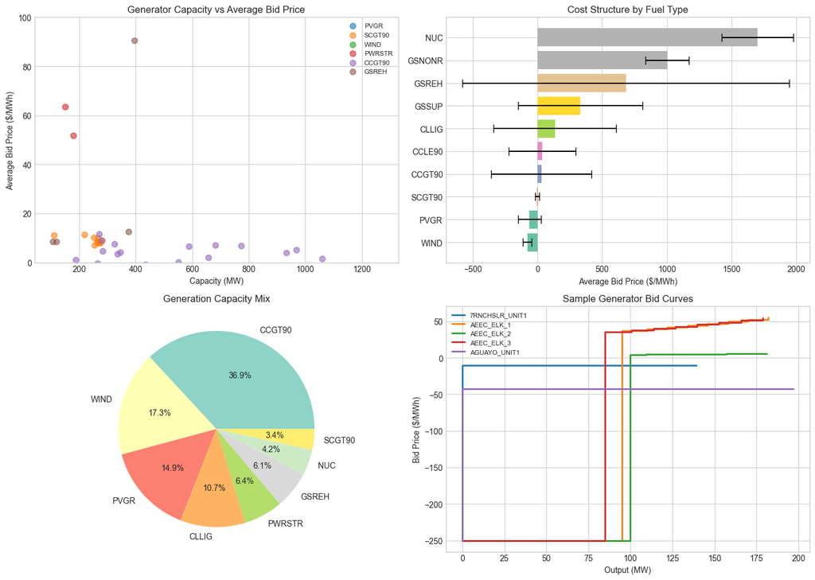

```python
fig, axes = plt.subplots(2, 2, figsize=(14, 10))

ax = axes[0, 0]
for rtype in gen_sample['RES_TYPE'].dropna().unique()[:6]:
    subset = gen_sample[gen_sample['RES_TYPE'] == rtype]
    ax.scatter(subset['capacity'], subset['avg_bid_price'], label=rtype, alpha=0.6, s=50)
ax.set_xlabel('Capacity (MW)')
ax.set_ylabel('Average Bid Price ($/MWh)')
ax.set_title('Generator Capacity vs Average Bid Price')
ax.legend(fontsize=8)
ax.set_ylim(0, 100)

ax = axes[0, 1]
cost_by_type = gen_sample.groupby('RES_TYPE')['avg_bid_price'].agg(['mean', 'std']).dropna().sort_values('mean').head(10)
colors = plt.cm.Set2(np.linspace(0, 1, len(cost_by_type)))
bars = ax.barh(cost_by_type.index, cost_by_type['mean'], xerr=cost_by_type['std'].fillna(0), color=colors, capsize=5)
ax.set_xlabel('Average Bid Price ($/MWh)')
ax.set_title('Cost Structure by Fuel Type')

ax = axes[1, 0]
capacity_by_type = gen_sample.groupby('RES_TYPE')['capacity'].sum().sort_values(ascending=False).head(8)
ax.pie(capacity_by_type.values, labels=capacity_by_type.index, autopct='%1.1f%%',
       colors=plt.cm.Set3(np.linspace(0, 1, len(capacity_by_type))))
ax.set_title('Generation Capacity Mix')

ax = axes[1, 1]
sample_gens = gen_sample[gen_sample['avg_bid_price'].notna()].head(5)
for _, row in sample_gens.iterrows():
    if len(row['quantities']) > 1:
        ax.step(row['quantities'], row['prices'], where='post', label=row['RES_NAME'][:20], linewidth=2)
ax.set_xlabel('Output (MW)')
ax.set_ylabel('Bid Price ($/MWh)')
ax.set_title('Sample Generator Bid Curves')
ax.legend(fontsize=8)

plt.tight_layout()
plt.show()
```

## 3. Cournot Competition Model

In Cournot competition, generators choose quantities simultaneously to maximize profit.

**Model Setup:**

- N generators with marginal costs $c_i$ and capacities $K_i$
- Inverse demand: $P(Q) = a - bQ$ where $Q = \sum q_i$
- Profit: $\pi_i = (P(Q) - c_i) \cdot q_i$
- Best response: $q_i^* = \frac{a - c_i - b \sum_{j \neq i} q_j}{2b}$

```python
class CournotGame:
    """Cournot quantity competition model for electricity markets"""

    def __init__(self, generators, demand_intercept=100, demand_slope=0.001):
        """
        generators: dict of {name: {'cost': marginal_cost, 'capacity': max_capacity}}
        demand_intercept (a): P when Q=0
        demand_slope (b): price sensitivity to quantity
        """
        self.generators = generators
        self.a = demand_intercept
        self.b = demand_slope
        self.names = list(generators.keys())
        self.n = len(self.names)

    def price(self, total_quantity):
        """Inverse demand function: P(Q) = a - bQ"""
        return max(0, self.a - self.b * total_quantity)

    def profit(self, name, quantities):
        """Calculate profit for generator 'name' given all quantities"""
        total_q = sum(quantities.values())
        p = self.price(total_q)
        q_i = quantities[name]
        c_i = self.generators[name]['cost']
        return (p - c_i) * q_i

    def best_response(self, name, other_quantities):
        """Calculate best response quantity for generator 'name'"""
        q_others = sum(other_quantities.values())
        c_i = self.generators[name]['cost']
        k_i = self.generators[name]['capacity']

        q_star = (self.a - c_i - self.b * q_others) / (2 * self.b)
        return max(0, min(q_star, k_i))

    def solve_nash_equilibrium(self, max_iterations=100, tolerance=1e-6):
        """Iteratively solve for Nash equilibrium using best response dynamics"""
        quantities = {name: self.generators[name]['capacity'] / 2 for name in self.names}

        for iteration in range(max_iterations):
            old_quantities = quantities.copy()

            for name in self.names:
                others = {n: q for n, q in quantities.items() if n != name}
                quantities[name] = self.best_response(name, others)

            if max(abs(quantities[n] - old_quantities[n]) for n in self.names) < tolerance:
                break

        total_q = sum(quantities.values())
        eq_price = self.price(total_q)
        profits = {name: self.profit(name, quantities) for name in self.names}

        return {
            'quantities': quantities,
            'price': eq_price,
            'profits': profits,
            'total_quantity': total_q,
            'iterations': iteration + 1
        }

    def market_power_index(self, equilibrium):
        """Calculate Lerner Index (market power measure)"""
        p = equilibrium['price']
        lerners = {}
        for name in self.names:
            c = self.generators[name]['cost']
            lerners[name] = (p - c) / p if p > 0 else 0
        return lerners
```

```python
top_generators = gen_sample.nlargest(10, 'capacity')[['RES_NAME', 'RES_TYPE', 'capacity', 'avg_bid_price']].dropna()

generators = {}
for _, row in top_generators.iterrows():
    name = row['RES_NAME'][:15]
    generators[name] = {
        'cost': float(row['avg_bid_price']) if pd.notna(row['avg_bid_price']) else 25.0,
        'capacity': float(row['capacity']),
        'type': row['RES_TYPE']
    }

print("Top 10 Generators for Cournot Model:")
for name, data in generators.items():
    print(f"  {name}: Cost=${data['cost']:.2f}/MWh, Capacity={data['capacity']:.0f}MW ({data['type']})")
```

```
Top 10 Generators for Cournot Model:
  DDPEC_CC1_6: Cost=$-2.96/MWh, Capacity=1271MW (CCGT90)
  CPSES_UNIT1: Cost=$1850.00/MWh, Capacity=1234MW (NUC)
  CPSES_UNIT2: Cost=$1850.00/MWh, Capacity=1215MW (NUC)
  CBECII_CC3_2: Cost=$-24.66/MWh, Capacity=1146MW (CCGT90)
  DDPEC_CC1_4: Cost=$1.62/MWh, Capacity=1060MW (CCGT90)
  FRNYPP_CC2_6: Cost=$5.12/MWh, Capacity=969MW (CCGT90)
  FRNYPP_CC1_6: Cost=$3.93/MWh, Capacity=932MW (CCGT90)
  OGSES_UNIT1A: Cost=$-23.27/MWh, Capacity=855MW (CLLIG)
  LEG_LEG_G1: Cost=$990.95/MWh, Capacity=831MW (CLLIG)
  OGSES_UNIT2: Cost=$-23.37/MWh, Capacity=830MW (CLLIG)
```

```python
avg_price = price_df['RT_PRICE'].mean()
total_capacity = sum(g['capacity'] for g in generators.values())

demand_intercept = avg_price * 1.5
demand_slope = avg_price / (total_capacity * 1.2)

game = CournotGame(generators, demand_intercept=demand_intercept, demand_slope=demand_slope)
equilibrium = game.solve_nash_equilibrium()

print("=" * 70)
print("COURNOT NASH EQUILIBRIUM")
print("=" * 70)
print(f"\nEquilibrium Price: ${equilibrium['price']:.2f}/MWh")
print(f"Total Output: {equilibrium['total_quantity']:,.0f} MW")
print(f"Converged in {equilibrium['iterations']} iterations")

print("\nGenerator Outputs and Profits:")
print("-" * 70)
for name in sorted(equilibrium['quantities'].keys(), key=lambda x: -equilibrium['quantities'][x]):
    q = equilibrium['quantities'][name]
    pi = equilibrium['profits'][name]
    cap = generators[name]['capacity']
    util = q / cap * 100
    print(f"  {name:15s}: Output={q:7,.0f} MW ({util:5.1f}% util), Profit=${pi:12,.0f}")
```

```
======================================================================
COURNOT NASH EQUILIBRIUM
======================================================================

Equilibrium Price: $89.19/MWh
Total Output: 7,063 MW
Converged in 2 iterations

Generator Outputs and Profits:
----------------------------------------------------------------------
  DDPEC_CC1_6    : Output=  1,271 MW (100.0% util), Profit=$     117,122
  CBECII_CC3_2   : Output=  1,146 MW (100.0% util), Profit=$     130,419
  DDPEC_CC1_4    : Output=  1,060 MW (100.0% util), Profit=$      92,825
  FRNYPP_CC2_6   : Output=    969 MW (100.0% util), Profit=$      81,488
  FRNYPP_CC1_6   : Output=    932 MW (100.0% util), Profit=$      79,469
  OGSES_UNIT1A   : Output=    855 MW (100.0% util), Profit=$      96,151
  OGSES_UNIT2    : Output=    830 MW (100.0% util), Profit=$      93,429
  CPSES_UNIT1    : Output=      0 MW (  0.0% util), Profit=$          -0
  CPSES_UNIT2    : Output=      0 MW (  0.0% util), Profit=$          -0
  LEG_LEG_G1     : Output=      0 MW (  0.0% util), Profit=$          -0
```

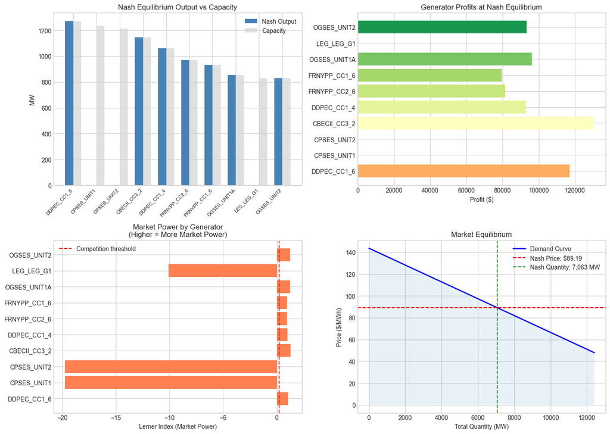

```python
fig, axes = plt.subplots(2, 2, figsize=(14, 10))

ax = axes[0, 0]
names = list(equilibrium['quantities'].keys())
quantities = [equilibrium['quantities'][n] for n in names]
capacities = [generators[n]['capacity'] for n in names]
x = np.arange(len(names))
width = 0.35
bars1 = ax.bar(x - width/2, quantities, width, label='Nash Output', color='steelblue')
bars2 = ax.bar(x + width/2, capacities, width, label='Capacity', color='lightgray', alpha=0.7)
ax.set_ylabel('MW')
ax.set_title('Nash Equilibrium Output vs Capacity')
ax.set_xticks(x)
ax.set_xticklabels(names, rotation=45, ha='right', fontsize=8)
ax.legend()

ax = axes[0, 1]
profits = [equilibrium['profits'][n] for n in names]
colors = plt.cm.RdYlGn(np.linspace(0.3, 0.9, len(names)))
ax.barh(names, profits, color=colors)
ax.set_xlabel('Profit ($)')
ax.set_title('Generator Profits at Nash Equilibrium')
ax.axvline(x=0, color='black', linewidth=0.5)

ax = axes[1, 0]
lerners = game.market_power_index(equilibrium)
lerner_vals = [lerners[n] for n in names]
ax.barh(names, lerner_vals, color='coral')
ax.set_xlabel('Lerner Index (Market Power)')
ax.set_title('Market Power by Generator\n(Higher = More Market Power)')
ax.axvline(x=0.2, color='red', linestyle='--', label='Competition threshold')
ax.legend()

ax = axes[1, 1]
Q_range = np.linspace(0, total_capacity * 1.2, 100)
P_range = [game.price(q) for q in Q_range]
ax.plot(Q_range, P_range, 'b-', linewidth=2, label='Demand Curve')
ax.axhline(y=equilibrium['price'], color='red', linestyle='--', label=f'Nash Price: ${equilibrium["price"]:.2f}')
ax.axvline(x=equilibrium['total_quantity'], color='green', linestyle='--', label=f'Nash Quantity: {equilibrium["total_quantity"]:,.0f} MW')
ax.fill_between(Q_range, P_range, alpha=0.1)
ax.set_xlabel('Total Quantity (MW)')
ax.set_ylabel('Price ($/MWh)')
ax.set_title('Market Equilibrium')
ax.legend()

plt.tight_layout()
plt.show()
```

## 4. Stackelberg Competition Model

In Stackelberg competition, a dominant firm (leader) moves first, and smaller firms (followers) react.

**Model Setup:**

- Leader commits to quantity $q_L$ first
- Followers observe $q_L$ and choose best response $q_F^*(q_L)$
- Leader anticipates follower response and optimizes accordingly

```python
class StackelbergGame:
    """Stackelberg leader-follower competition model"""

    def __init__(self, leader, followers, demand_intercept=100, demand_slope=0.001):
        self.leader = leader
        self.followers = followers
        self.a = demand_intercept
        self.b = demand_slope

    def price(self, total_quantity):
        return max(0, self.a - self.b * total_quantity)

    def follower_best_response(self, leader_quantity):
        """Aggregate follower best response to leader quantity"""
        follower_outputs = {}
        for name, data in self.followers.items():
            q_star = (self.a - data['cost'] - self.b * leader_quantity) / (2 * self.b * len(self.followers))
            q_star = max(0, min(q_star, data['capacity']))
            follower_outputs[name] = q_star
        return follower_outputs

    def leader_profit(self, leader_quantity):
        """Leader profit anticipating follower response"""
        follower_outputs = self.follower_best_response(leader_quantity)
        total_follower = sum(follower_outputs.values())
        total_q = leader_quantity + total_follower
        p = self.price(total_q)
        return (p - self.leader['cost']) * leader_quantity

    def solve_equilibrium(self):
        """Find Stackelberg equilibrium"""
        result = minimize_scalar(
            lambda q: -self.leader_profit(q),
            bounds=(0, self.leader['capacity']),
            method='bounded'
        )

        leader_q = result.x
        follower_outputs = self.follower_best_response(leader_q)
        total_q = leader_q + sum(follower_outputs.values())
        eq_price = self.price(total_q)

        leader_profit = (eq_price - self.leader['cost']) * leader_q
        follower_profits = {
            name: (eq_price - data['cost']) * follower_outputs[name]
            for name, data in self.followers.items()
        }

        return {
            'leader_quantity': leader_q,
            'follower_quantities': follower_outputs,
            'price': eq_price,
            'leader_profit': leader_profit,
            'follower_profits': follower_profits,
            'total_quantity': total_q
        }
```

```python
sorted_gens = sorted(generators.items(), key=lambda x: -x[1]['capacity'])
leader_name, leader_data = sorted_gens[0]
followers = {name: data for name, data in sorted_gens[1:6]}

print(f"Leader: {leader_name} (Capacity: {leader_data['capacity']:,.0f} MW)")
print(f"Followers: {', '.join(followers.keys())}")

stackelberg = StackelbergGame(leader_data, followers, demand_intercept, demand_slope)
stack_eq = stackelberg.solve_equilibrium()

print("\n" + "=" * 70)
print("STACKELBERG EQUILIBRIUM")
print("=" * 70)
print(f"\nEquilibrium Price: ${stack_eq['price']:.2f}/MWh")
print(f"\nLeader ({leader_name}):")
print(f"  Output: {stack_eq['leader_quantity']:,.0f} MW")
print(f"  Profit: ${stack_eq['leader_profit']:,.0f}")

print("\nFollowers:")
for name, q in stack_eq['follower_quantities'].items():
    profit = stack_eq['follower_profits'][name]
    print(f"  {name}: Output={q:,.0f} MW, Profit=${profit:,.0f}")
```

```
Leader: DDPEC_CC1_6 (Capacity: 1,271 MW)
Followers: CPSES_UNIT1, CPSES_UNIT2, CBECII_CC3_2, DDPEC_CC1_4, FRNYPP_CC2_6

======================================================================
STACKELBERG EQUILIBRIUM
======================================================================

Equilibrium Price: $109.40/MWh

Leader (DDPEC_CC1_6):
  Output: 1,271 MW
  Profit: $142,799

Followers:
  CPSES_UNIT1: Output=0 MW, Profit=$-0
  CPSES_UNIT2: Output=0 MW, Profit=$-0
  CBECII_CC3_2: Output=1,146 MW, Profit=$153,561
  DDPEC_CC1_4: Output=1,060 MW, Profit=$114,239
  FRNYPP_CC2_6: Output=969 MW, Profit=$101,070
```

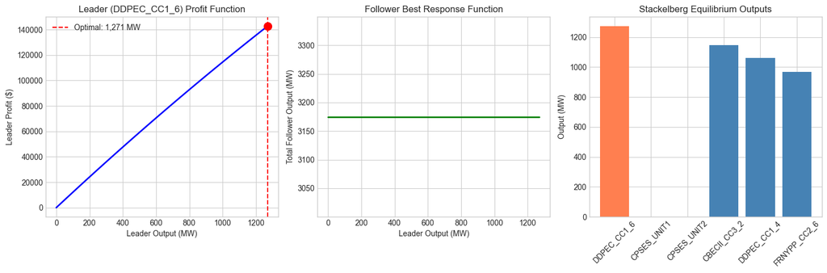

```
Comparison: Cournot vs Stackelberg
--------------------------------------------------
Cournot Price:     $89.19/MWh
Stackelberg Price: $109.40/MWh
Price Difference:  $-20.20/MWh

Leader advantage: $25,677
```

```python
fig, axes = plt.subplots(1, 3, figsize=(15, 5))

ax = axes[0]
leader_quantities = np.linspace(0, leader_data['capacity'], 50)
leader_profits = [stackelberg.leader_profit(q) for q in leader_quantities]
ax.plot(leader_quantities, leader_profits, 'b-', linewidth=2)
ax.axvline(x=stack_eq['leader_quantity'], color='red', linestyle='--', label=f'Optimal: {stack_eq["leader_quantity"]:,.0f} MW')
ax.scatter([stack_eq['leader_quantity']], [stack_eq['leader_profit']], color='red', s=100, zorder=5)
ax.set_xlabel('Leader Output (MW)')
ax.set_ylabel('Leader Profit ($)')
ax.set_title(f'Leader ({leader_name}) Profit Function')
ax.legend()

ax = axes[1]
follower_responses = []
for lq in leader_quantities:
    fr = stackelberg.follower_best_response(lq)
    follower_responses.append(sum(fr.values()))
ax.plot(leader_quantities, follower_responses, 'g-', linewidth=2)
ax.set_xlabel('Leader Output (MW)')
ax.set_ylabel('Total Follower Output (MW)')
ax.set_title('Follower Best Response Function')

ax = axes[2]
labels = [leader_name] + list(stack_eq['follower_quantities'].keys())
values = [stack_eq['leader_quantity']] + list(stack_eq['follower_quantities'].values())
colors = ['coral'] + ['steelblue'] * len(stack_eq['follower_quantities'])
ax.bar(labels, values, color=colors)
ax.set_ylabel('Output (MW)')
ax.set_title('Stackelberg Equilibrium Outputs')
ax.tick_params(axis='x', rotation=45)

plt.tight_layout()
plt.show()

print("\nComparison: Cournot vs Stackelberg")
print("-" * 50)
print(f"Cournot Price:     ${equilibrium['price']:.2f}/MWh")
print(f"Stackelberg Price: ${stack_eq['price']:.2f}/MWh")
print(f"Price Difference:  ${equilibrium['price'] - stack_eq['price']:.2f}/MWh")
print(f"\nLeader advantage: ${stack_eq['leader_profit'] - equilibrium['profits'].get(leader_name, 0):,.0f}")
```

## 5. Supply Function Equilibrium (SFE)

In electricity markets, generators submit bid curves (supply functions) rather than just quantities.

**Model Setup:**

- Each generator submits $q_i(p)$ - quantity as function of price
- Market clears where $D(p) = \sum_i q_i(p)$
- Strategic generators choose slope of their supply function

```python
class SupplyFunctionEquilibrium:
    """Supply Function Equilibrium model for electricity auctions"""

    def __init__(self, generators, demand_intercept=100, demand_slope=0.001):
        self.generators = generators
        self.a = demand_intercept
        self.b = demand_slope
        self.names = list(generators.keys())

    def demand(self, price):
        """Demand function: Q(P) = (a - P) / b"""
        return max(0, (self.a - price) / self.b)

    def supply_function(self, price, cost, slope):
        """Linear supply function: q(p) = slope * (p - c) for p > c"""
        if price <= cost:
            return 0
        return slope * (price - cost)

    def market_clearing_price(self, slopes):
        """Find price where supply equals demand"""
        def excess_demand(p):
            total_supply = sum(
                self.supply_function(p, self.generators[name]['cost'], slopes[name])
                for name in self.names
            )
            return self.demand(p) - total_supply

        from scipy.optimize import brentq
        try:
            p_star = brentq(excess_demand, 0.01, self.a)
        except:
            p_star = self.a / 2
        return p_star

    def generator_profit(self, name, slopes):
        """Calculate profit for generator given all supply function slopes"""
        p = self.market_clearing_price(slopes)
        q = self.supply_function(p, self.generators[name]['cost'], slopes[name])
        q = min(q, self.generators[name]['capacity'])
        return (p - self.generators[name]['cost']) * q

    def best_response_slope(self, name, other_slopes):
        """Find best response slope for generator 'name'"""
        def neg_profit(slope):
            slopes = other_slopes.copy()
            slopes[name] = slope
            return -self.generator_profit(name, slopes)

        result = minimize_scalar(neg_profit, bounds=(0.1, 1000), method='bounded')
        return result.x

    def solve_equilibrium(self, max_iterations=50, tolerance=1e-4):
        """Solve for SFE using best response dynamics"""
        slopes = {name: 50 for name in self.names}

        for iteration in range(max_iterations):
            old_slopes = slopes.copy()

            for name in self.names:
                others = {n: s for n, s in slopes.items() if n != name}
                slopes[name] = self.best_response_slope(name, slopes)

            if max(abs(slopes[n] - old_slopes[n]) / (old_slopes[n] + 1e-6) for n in self.names) < tolerance:
                break

        eq_price = self.market_clearing_price(slopes)
        quantities = {
            name: min(self.supply_function(eq_price, self.generators[name]['cost'], slopes[name]),
                     self.generators[name]['capacity'])
            for name in self.names
        }
        profits = {name: self.generator_profit(name, slopes) for name in self.names}

        return {
            'slopes': slopes,
            'price': eq_price,
            'quantities': quantities,
            'profits': profits,
            'iterations': iteration + 1
        }
```

```python
top_5_gens = {name: data for name, data in list(generators.items())[:5]}

sfe = SupplyFunctionEquilibrium(top_5_gens, demand_intercept, demand_slope)
sfe_eq = sfe.solve_equilibrium()

print("=" * 70)
print("SUPPLY FUNCTION EQUILIBRIUM")
print("=" * 70)
print(f"\nEquilibrium Price: ${sfe_eq['price']:.2f}/MWh")
print(f"Converged in {sfe_eq['iterations']} iterations")

print("\nGenerator Supply Functions and Outcomes:")
print("-" * 70)
for name in sfe_eq['slopes'].keys():
    slope = sfe_eq['slopes'][name]
    q = sfe_eq['quantities'][name]
    profit = sfe_eq['profits'][name]
    cost = top_5_gens[name]['cost']
    print(f"  {name:15s}: Slope={slope:6.1f}, Cost=${cost:.1f}, Output={q:6,.0f} MW, Profit=${profit:10,.0f}")
```

```
======================================================================
SUPPLY FUNCTION EQUILIBRIUM
======================================================================

Equilibrium Price: $116.88/MWh
Converged in 5 iterations

Generator Supply Functions and Outcomes:
----------------------------------------------------------------------
  DDPEC_CC1_6    : Slope=  10.6, Cost=$-3.0, Output= 1,271 MW, Profit=$   152,310
  CPSES_UNIT1    : Slope=1000.0, Cost=$1850.0, Output=     0 MW, Profit=$        -0
  CPSES_UNIT2    : Slope=1000.0, Cost=$1850.0, Output=     0 MW, Profit=$        -0
  CBECII_CC3_2   : Slope=   8.1, Cost=$-24.7, Output= 1,146 MW, Profit=$   162,132
  DDPEC_CC1_4    : Slope=   9.2, Cost=$1.6, Output= 1,060 MW, Profit=$   122,171
```

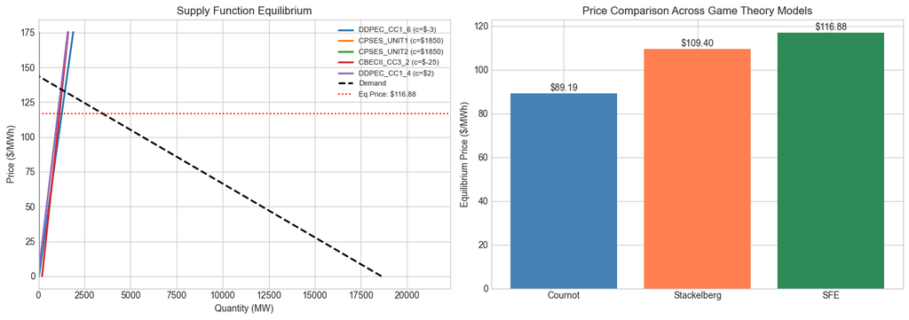

```python
fig, axes = plt.subplots(1, 2, figsize=(14, 5))

ax = axes[0]
price_range = np.linspace(0, sfe_eq['price'] * 1.5, 100)
for name in sfe_eq['slopes'].keys():
    cost = top_5_gens[name]['cost']
    slope = sfe_eq['slopes'][name]
    supply = [sfe.supply_function(p, cost, slope) for p in price_range]
    ax.plot(supply, price_range, label=f"{name} (c=${cost:.0f})", linewidth=2)

demand_curve = [sfe.demand(p) for p in price_range]
ax.plot(demand_curve, price_range, 'k--', linewidth=2, label='Demand')
ax.axhline(y=sfe_eq['price'], color='red', linestyle=':', label=f'Eq Price: ${sfe_eq["price"]:.2f}')
ax.set_xlabel('Quantity (MW)')
ax.set_ylabel('Price ($/MWh)')
ax.set_title('Supply Function Equilibrium')
ax.legend(fontsize=8)
ax.set_xlim(0, max(demand_curve) * 1.2)

ax = axes[1]
models = ['Cournot', 'Stackelberg', 'SFE']
prices = [equilibrium['price'], stack_eq['price'], sfe_eq['price']]
colors = ['steelblue', 'coral', 'seagreen']
bars = ax.bar(models, prices, color=colors)
ax.set_ylabel('Equilibrium Price ($/MWh)')
ax.set_title('Price Comparison Across Game Theory Models')
for bar, price in zip(bars, prices):
    ax.text(bar.get_x() + bar.get_width()/2, bar.get_height() + 0.5,
            f'${price:.2f}', ha='center', va='bottom', fontsize=10)

plt.tight_layout()
plt.show()
```

## 6. Repeated Games & Tacit Collusion

In repeated interactions, generators may learn to coordinate on higher prices.

**Collusion Sustainability Condition (Folk Theorem):**

- Collusion is sustainable if $\frac{\pi_{collusion}}{1-\delta} > \pi_{deviate} + \frac{\delta \cdot \pi_{nash}}{1-\delta}$
- Where $\delta$ is the discount factor (patience)

```python
class RepeatedCournotGame:
    """Repeated Cournot game with collusion analysis"""

    def __init__(self, cournot_game):
        self.game = cournot_game

    def collusive_outcome(self, collusion_factor=0.5):
        """Calculate collusive outcome (restrict output to raise price)"""
        nash_eq = self.game.solve_nash_equilibrium()

        collusive_quantities = {
            name: nash_eq['quantities'][name] * collusion_factor
            for name in self.game.names
        }

        total_q = sum(collusive_quantities.values())
        collusive_price = self.game.price(total_q)
        collusive_profits = {
            name: (collusive_price - self.game.generators[name]['cost']) * collusive_quantities[name]
            for name in self.game.names
        }

        return {
            'quantities': collusive_quantities,
            'price': collusive_price,
            'profits': collusive_profits
        }

    def deviation_profit(self, deviator, collusive_quantities):
        """Profit from deviating while others collude"""
        others_output = sum(q for name, q in collusive_quantities.items() if name != deviator)

        best_q = 0
        best_profit = -np.inf
        for q in np.linspace(0, self.game.generators[deviator]['capacity'], 100):
            total_q = q + others_output
            p = self.game.price(total_q)
            profit = (p - self.game.generators[deviator]['cost']) * q
            if profit > best_profit:
                best_profit = profit
                best_q = q

        return best_profit, best_q

    def critical_discount_factor(self, deviator, collusion_factor=0.5):
        """Calculate minimum discount factor for collusion sustainability"""
        nash_eq = self.game.solve_nash_equilibrium()
        collusive = self.collusive_outcome(collusion_factor)

        pi_collusion = collusive['profits'][deviator]
        pi_nash = nash_eq['profits'][deviator]
        pi_deviate, _ = self.deviation_profit(deviator, collusive['quantities'])

        if pi_deviate - pi_collusion <= 0:
            return 0

        delta_star = (pi_deviate - pi_collusion) / (pi_deviate - pi_nash)
        return delta_star

    def simulate_repeated_game(self, periods=100, discount_factor=0.9, trigger_strategy=True):
        """Simulate repeated game with trigger strategies"""
        nash_eq = self.game.solve_nash_equilibrium()
        collusive = self.collusive_outcome(0.6)

        history = []
        current_regime = 'collusion'

        for t in range(periods):
            if current_regime == 'collusion':
                if trigger_strategy and np.random.random() < 0.05:
                    current_regime = 'punishment'
                    outcome = nash_eq
                else:
                    outcome = collusive
            else:
                outcome = nash_eq
                if np.random.random() < 0.1:
                    current_regime = 'collusion'

            history.append({
                'period': t,
                'regime': current_regime,
                'price': outcome['price'],
                'total_output': sum(outcome['quantities'].values()),
                'total_profit': sum(outcome['profits'].values())
            })

        return pd.DataFrame(history)
```

```
======================================================================
COLLUSION ANALYSIS
======================================================================

Nash Equilibrium Price:  $89.19/MWh
Collusive Price (60%):   $111.00/MWh
Price Markup:            24.5%

Critical Discount Factors (min patience for sustainable collusion):
--------------------------------------------------
  DDPEC_CC1_6    : δ* = 2.451  ✗ Unstable
  CPSES_UNIT1    : δ* = 0.000  ✓ Sustainable
  CPSES_UNIT2    : δ* = 0.000  ✓ Sustainable
  CBECII_CC3_2   : δ* = 2.896  ✗ Unstable
  DDPEC_CC1_4    : δ* = 2.301  ✗ Unstable
```

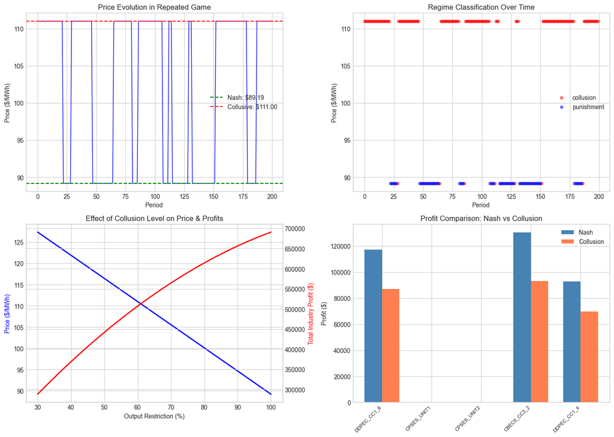

```python
repeated_game = RepeatedCournotGame(game)
collusive = repeated_game.collusive_outcome(0.6)

print("=" * 70)
print("COLLUSION ANALYSIS")
print("=" * 70)

print(f"\nNash Equilibrium Price:  ${equilibrium['price']:.2f}/MWh")
print(f"Collusive Price (60%):   ${collusive['price']:.2f}/MWh")
print(f"Price Markup:            {(collusive['price']/equilibrium['price'] - 1)*100:.1f}%")

print("\nCritical Discount Factors (min patience for sustainable collusion):")
print("-" * 50)
for name in list(generators.keys())[:5]:
    delta_star = repeated_game.critical_discount_factor(name)
    sustainable = "✓ Sustainable" if delta_star < 0.95 else "✗ Unstable"
    print(f"  {name:15s}: δ* = {delta_star:.3f}  {sustainable}")

simulation = repeated_game.simulate_repeated_game(periods=200)

fig, axes = plt.subplots(2, 2, figsize=(14, 10))

ax = axes[0, 0]
ax.plot(simulation['period'], simulation['price'], 'b-', linewidth=1)
ax.axhline(y=equilibrium['price'], color='green', linestyle='--', label=f'Nash: ${equilibrium["price"]:.2f}')
ax.axhline(y=collusive['price'], color='red', linestyle='--', label=f'Collusive: ${collusive["price"]:.2f}')
ax.set_xlabel('Period')
ax.set_ylabel('Price ($/MWh)')
ax.set_title('Price Evolution in Repeated Game')
ax.legend()

ax = axes[0, 1]
regime_colors = {'collusion': 'red', 'punishment': 'blue'}
for regime in ['collusion', 'punishment']:
    mask = simulation['regime'] == regime
    ax.scatter(simulation.loc[mask, 'period'], simulation.loc[mask, 'price'],
               c=regime_colors[regime], label=regime, alpha=0.5, s=20)
ax.set_xlabel('Period')
ax.set_ylabel('Price ($/MWh)')
ax.set_title('Regime Classification Over Time')
ax.legend()

ax = axes[1, 0]
collusion_factors = np.linspace(0.3, 1.0, 20)
prices_by_factor = []
profits_by_factor = []
for cf in collusion_factors:
    outcome = repeated_game.collusive_outcome(cf)
    prices_by_factor.append(outcome['price'])
    profits_by_factor.append(sum(outcome['profits'].values()))

ax.plot(collusion_factors * 100, prices_by_factor, 'b-', linewidth=2, label='Price')
ax.set_xlabel('Output Restriction (%)')
ax.set_ylabel('Price ($/MWh)', color='blue')
ax2 = ax.twinx()
ax2.plot(collusion_factors * 100, profits_by_factor, 'r-', linewidth=2, label='Total Profit')
ax2.set_ylabel('Total Industry Profit ($)', color='red')
ax.set_title('Effect of Collusion Level on Price & Profits')

ax = axes[1, 1]
nash_profits = list(equilibrium['profits'].values())[:5]
collusive_profits = list(collusive['profits'].values())[:5]
names_short = list(generators.keys())[:5]
x = np.arange(len(names_short))
width = 0.35
ax.bar(x - width/2, nash_profits, width, label='Nash', color='steelblue')
ax.bar(x + width/2, collusive_profits, width, label='Collusion', color='coral')
ax.set_ylabel('Profit ($)')
ax.set_title('Profit Comparison: Nash vs Collusion')
ax.set_xticks(x)
ax.set_xticklabels(names_short, rotation=45, ha='right', fontsize=8)
ax.legend()

plt.tight_layout()
plt.show()
```

## 7. Congestion-Induced Market Power

When transmission constraints bind, the market splits into local regions where generators can exercise localized market power.

**Spatial Cournot Model:**

- Zones connected by transmission lines with limited capacity
- When constraints bind, generators in importing zones gain market power

```python
class SpatialCournotGame:
    """Cournot competition with transmission constraints"""

    def __init__(self, zones, transmission_limits):
        """
        zones: dict of {zone_name: {'generators': {...}, 'demand_intercept': a, 'demand_slope': b}}
        transmission_limits: dict of {(from_zone, to_zone): MW_limit}
        """
        self.zones = zones
        self.transmission_limits = transmission_limits
        self.zone_names = list(zones.keys())

    def solve_unconstrained(self):
        """Solve as if single market (no congestion)"""
        all_gens = {}
        for zone_name, zone_data in self.zones.items():
            for gen_name, gen_data in zone_data['generators'].items():
                all_gens[f"{zone_name}_{gen_name}"] = gen_data

        total_a = sum(z['demand_intercept'] for z in self.zones.values())
        total_b = sum(z['demand_slope'] for z in self.zones.values()) / len(self.zones)

        game = CournotGame(all_gens, total_a, total_b)
        return game.solve_nash_equilibrium()

    def solve_zonal(self):
        """Solve each zone independently (full congestion)"""
        zonal_results = {}
        for zone_name, zone_data in self.zones.items():
            game = CournotGame(
                zone_data['generators'],
                zone_data['demand_intercept'],
                zone_data['demand_slope']
            )
            zonal_results[zone_name] = game.solve_nash_equilibrium()
        return zonal_results

    def calculate_congestion_rents(self, zonal_results):
        """Calculate congestion revenue from price differences"""
        rents = {}
        for (from_zone, to_zone), limit in self.transmission_limits.items():
            price_diff = zonal_results[to_zone]['price'] - zonal_results[from_zone]['price']
            if price_diff > 0:
                rents[(from_zone, to_zone)] = price_diff * limit
            else:
                rents[(from_zone, to_zone)] = 0
        return rents
```

```python
zones = {
    'HOUSTON': {
        'generators': {
            'Houston_CC_1': {'cost': 28, 'capacity': 800},
            'Houston_CC_2': {'cost': 32, 'capacity': 600},
            'Houston_CT': {'cost': 45, 'capacity': 400}
        },
        'demand_intercept': 60,
        'demand_slope': 0.02
    },
    'NORTH': {
        'generators': {
            'North_Wind': {'cost': 5, 'capacity': 1500},
            'North_Gas': {'cost': 30, 'capacity': 700},
            'North_Coal': {'cost': 25, 'capacity': 900}
        },
        'demand_intercept': 55,
        'demand_slope': 0.025
    },
    'SOUTH': {
        'generators': {
            'South_Nuclear': {'cost': 8, 'capacity': 2500},
            'South_Gas': {'cost': 35, 'capacity': 500}
        },
        'demand_intercept': 45,
        'demand_slope': 0.015
    },
    'WEST': {
        'generators': {
            'West_Solar': {'cost': 3, 'capacity': 1200},
            'West_Wind': {'cost': 5, 'capacity': 800},
            'West_Gas': {'cost': 40, 'capacity': 300}
        },
        'demand_intercept': 40,
        'demand_slope': 0.03
    }
}

transmission_limits = {
    ('NORTH', 'HOUSTON'): 1500,
    ('SOUTH', 'HOUSTON'): 1000,
    ('WEST', 'NORTH'): 800,
    ('WEST', 'SOUTH'): 600
}

spatial_game = SpatialCournotGame(zones, transmission_limits)
unconstrained = spatial_game.solve_unconstrained()
zonal = spatial_game.solve_zonal()
congestion_rents = spatial_game.calculate_congestion_rents(zonal)

print("=" * 70)
print("SPATIAL MARKET ANALYSIS")
print("=" * 70)

print("\nUnconstrained Market (No Congestion):")
print(f"  System Price: ${unconstrained['price']:.2f}/MWh")

print("\nZonal Prices (Full Congestion):")
for zone_name, result in zonal.items():
    print(f"  {zone_name}: ${result['price']:.2f}/MWh")

print("\nCongestion Rents:")
for (from_z, to_z), rent in congestion_rents.items():
    if rent > 0:
        price_diff = zonal[to_z]['price'] - zonal[from_z]['price']
        print(f"  {from_z} → {to_z}: ${rent:,.0f} (price diff: ${price_diff:.2f}/MWh)")
```

```
======================================================================
SPATIAL MARKET ANALYSIS
======================================================================

Unconstrained Market (No Congestion):
  System Price: $39.89/MWh

Zonal Prices (Full Congestion):
  HOUSTON: $40.00/MWh
  NORTH: $28.33/MWh
  SOUTH: $26.50/MWh
  WEST: $16.00/MWh

Congestion Rents:
  NORTH → HOUSTON: $17,500 (price diff: $11.67/MWh)
  SOUTH → HOUSTON: $13,500 (price diff: $13.50/MWh)
  WEST → NORTH: $9,867 (price diff: $12.33/MWh)
  WEST → SOUTH: $6,300 (price diff: $10.50/MWh)
```

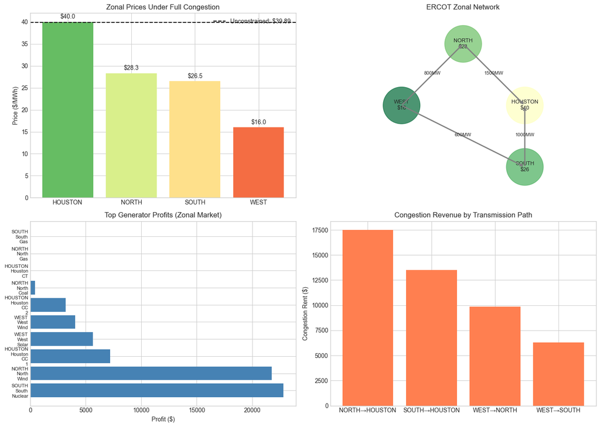

```python
fig, axes = plt.subplots(2, 2, figsize=(14, 10))

ax = axes[0, 0]
zone_names = list(zonal.keys())
zone_prices = [zonal[z]['price'] for z in zone_names]
colors = plt.cm.RdYlGn_r(np.linspace(0.2, 0.8, len(zone_names)))
bars = ax.bar(zone_names, zone_prices, color=colors)
ax.axhline(y=unconstrained['price'], color='black', linestyle='--',
           label=f'Unconstrained: ${unconstrained["price"]:.2f}')
ax.set_ylabel('Price ($/MWh)')
ax.set_title('Zonal Prices Under Full Congestion')
ax.legend()
for bar, price in zip(bars, zone_prices):
    ax.text(bar.get_x() + bar.get_width()/2, bar.get_height() + 0.5,
            f'${price:.1f}', ha='center', va='bottom')

ax = axes[0, 1]
zone_coords = {'HOUSTON': (2, 1), 'NORTH': (1, 2), 'SOUTH': (2, 0), 'WEST': (0, 1)}
for zone, (x, y) in zone_coords.items():
    price = zonal[zone]['price']
    color = plt.cm.RdYlGn_r((price - 20) / 40)
    circle = plt.Circle((x, y), 0.3, color=color, alpha=0.7)
    ax.add_patch(circle)
    ax.text(x, y, f'{zone}\n${price:.0f}', ha='center', va='center', fontsize=9)

for (from_z, to_z), limit in transmission_limits.items():
    x1, y1 = zone_coords[from_z]
    x2, y2 = zone_coords[to_z]
    ax.annotate('', xy=(x2, y2), xytext=(x1, y1),
                arrowprops=dict(arrowstyle='->', color='gray', lw=2))
    ax.text((x1+x2)/2, (y1+y2)/2, f'{limit}MW', fontsize=8, ha='center')

ax.set_xlim(-0.5, 2.5)
ax.set_ylim(-0.5, 2.5)
ax.set_aspect('equal')
ax.axis('off')
ax.set_title('ERCOT Zonal Network')

ax = axes[1, 0]
gen_profits = {}
for zone_name, result in zonal.items():
    for gen_name, profit in result['profits'].items():
        gen_profits[f"{zone_name}_{gen_name}"] = profit
sorted_profits = sorted(gen_profits.items(), key=lambda x: -x[1])[:10]
names_plot = [x[0].replace('_', '\n') for x in sorted_profits]
profits_plot = [x[1] for x in sorted_profits]
ax.barh(range(len(names_plot)), profits_plot, color='steelblue')
ax.set_yticks(range(len(names_plot)))
ax.set_yticklabels(names_plot, fontsize=8)
ax.set_xlabel('Profit ($)')
ax.set_title('Top Generator Profits (Zonal Market)')

ax = axes[1, 1]
rent_labels = [f'{f}→{t}' for (f, t), r in congestion_rents.items() if r > 0]
rent_values = [r for r in congestion_rents.values() if r > 0]
if rent_values:
    ax.bar(rent_labels, rent_values, color='coral')
    ax.set_ylabel('Congestion Rent ($)')
    ax.set_title('Congestion Revenue by Transmission Path')
else:
    ax.text(0.5, 0.5, 'No congestion\n(all paths unconstrained)',
            ha='center', va='center', transform=ax.transAxes)
    ax.set_title('Congestion Revenue')

plt.tight_layout()
plt.show()
```

## 8. Market Power Detection Using Real Data

Analyze actual ERCOT price patterns to detect potential strategic behavior.

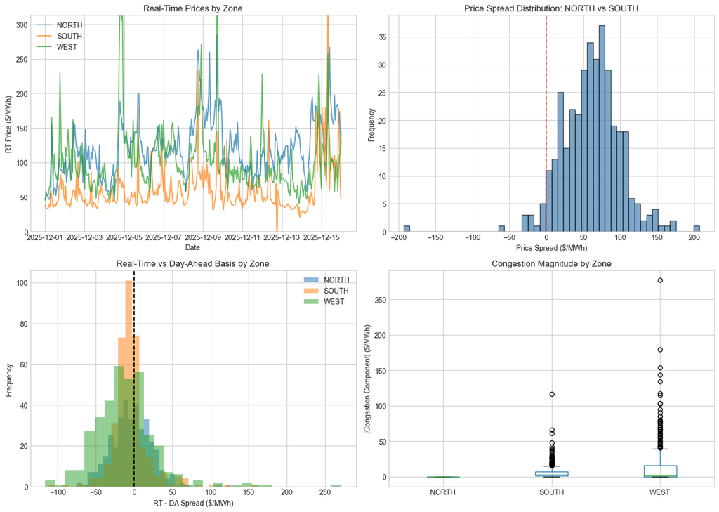

```python
price_wide = price_df.pivot_table(
    values=['RT_PRICE', 'DA_PRICE', 'RT_CONGESTION'],
    index='DATETIME',
    columns='ZONE'
).reset_index()
price_wide.columns = ['_'.join(col).strip('_') if isinstance(col, tuple) else col for col in price_wide.columns]

fig, axes = plt.subplots(2, 2, figsize=(14, 10))

ax = axes[0, 0]
for zone in ['HOUSTON', 'NORTH', 'SOUTH', 'WEST']:
    col = f'RT_PRICE_{zone}'
    if col in price_wide.columns:
        ax.plot(price_wide['DATETIME'], price_wide[col], label=zone, alpha=0.7)
ax.set_xlabel('Date')
ax.set_ylabel('RT Price ($/MWh)')
ax.set_title('Real-Time Prices by Zone')
ax.legend()
ax.set_ylim(0, price_wide[[c for c in price_wide.columns if 'RT_PRICE' in c]].quantile(0.99).max())

ax = axes[0, 1]
zone_cols = [c for c in price_wide.columns if 'RT_PRICE' in c]
if len(zone_cols) >= 2:
    spread = price_wide[zone_cols[0]] - price_wide[zone_cols[1]]
    ax.hist(spread.dropna(), bins=50, color='steelblue', alpha=0.7, edgecolor='black')
    ax.axvline(x=0, color='red', linestyle='--')
    ax.set_xlabel('Price Spread ($/MWh)')
    ax.set_ylabel('Frequency')
    ax.set_title(f'Price Spread Distribution: {zone_cols[0].split("_")[-1]} vs {zone_cols[1].split("_")[-1]}')

ax = axes[1, 0]
for zone in ['HOUSTON', 'NORTH', 'SOUTH', 'WEST']:
    rt_col = f'RT_PRICE_{zone}'
    da_col = f'DA_PRICE_{zone}'
    if rt_col in price_wide.columns and da_col in price_wide.columns:
        basis = price_wide[rt_col] - price_wide[da_col]
        ax.hist(basis.dropna(), bins=30, alpha=0.5, label=zone)
ax.axvline(x=0, color='black', linestyle='--')
ax.set_xlabel('RT - DA Spread ($/MWh)')
ax.set_ylabel('Frequency')
ax.set_title('Real-Time vs Day-Ahead Basis by Zone')
ax.legend()

ax = axes[1, 1]
cong_cols = [c for c in price_wide.columns if 'RT_CONGESTION' in c]
if cong_cols:
    cong_data = price_wide[cong_cols].abs()
    cong_data.columns = [c.split('_')[-1] for c in cong_cols]
    cong_data.boxplot(ax=ax)
    ax.set_ylabel('|Congestion Component| ($/MWh)')
    ax.set_title('Congestion Magnitude by Zone')

plt.tight_layout()
plt.show()
```